# 5조 EDA Project

5조

2019 7 4

# [ 5조: US Income Data를 이용한 인구통계학적 특성 분석 ]

### 4.2 Data handling

#### a) age.group:

#### 10대, 20대, 30대, 40대, 50대, 60대, 70대, 80대, 90대

#### b) education.group:

#### Assoc-acdm, Assoc-voc, Bachelors, Doctorate, Prof-school, Some-college

#### Hs-grad :(preschool, 1st-4th, 5-6th, 7-8th, 9th, 10th, 11th, 12th, Hs-grad )

#### c) hours.group:

#### 0-10, 10-20, 20-30, 30-40, 40-50, 50-60, 60-70, 70-80, 80-90, 90-100

### 5. 목차

#### 1. US income data 소개

#### (1) 주제 선정 이유

#### (2) 각 변수 소개

#### (3) 변수 handling 및 이유

#### 2. 단일 변수에 대한 분석

#### 3. 이변량 질적 자료에 대한 분석

#### 4. 질의응답

### 필요 패키지 설치 및 불러오기

#### 데이터 요약

```r
#install.packages("readxl")       # To import excel data
#install.packages("tidyverse")    # To handle and analysis data
#install.packages("writexl")      # To export excel data
#install.packages("RColorBrewer") # To get variety color
#install.packages("gridExtra")    # To display chart

library(readxl)
library(tidyverse)
library(writexl)
library(RColorBrewer)
library(gridExtra)
data <- readxl::read_excel(path = "d:/FastCampus/EDA프로젝트/데이터/adult.xlsx",)
```

```
## * `` -> ...1
```

```r
str(data)
```

```
## Classes 'tbl_df', 'tbl' and 'data.frame':    46033 obs. of  16 variables:
##  $ ...1           : num  0 1 2 3 5 7 8 9 10 11 ...
##  $ age            : num  25 38 28 44 34 63 24 55 65 36 ...
##  $ workclass      : chr  "Private" "Private" "Local-gov" "Private" ...
##  $ fnlwgt         : num  226802 89814 336951 160323 198693 ...
##  $ education      : chr  "11th" "HS-grad" "Assoc-acdm" "Some-college" ...
##  $ educational_num: num  7 9 12 10 6 15 10 4 9 13 ...
##  $ marital        : chr  "Never-married" "Married-civ-spouse" "Married-civ-spouse" "Married-civ-spouse" ...
##  $ occupation     : chr  "Machine-op-inspct" "Farming-fishing" "Protective-serv" "Machine-op-inspct" ...
##  $ relationship   : chr  "Own-child" "Husband" "Husband" "Husband" ...
##  $ race           : chr  "Black" "White" "White" "Black" ...
##  $ gender         : chr  "Male" "Male" "Male" "Male" ...
##  $ capital-gain   : num  0 0 0 7688 0 ...
##  $ capital-loss   : num  0 0 0 0 0 0 0 0 0 0 ...
##  $ hours_per_week : num  40 50 40 40 30 32 40 10 40 40 ...
##  $ native-country : chr  "United-States" "United-States" "United-States" "United-States" ...
##  $ income         : chr  "<=50K" "<=50K" ">50K" ">50K" ...
```

##### 46033 행 16개 변수

#### 데이터 핸들링

##### 필요 데이터 그룹핑

```r
data <- data.frame(data)

data1 <- data %>%
  dplyr::mutate(age.group = cut(age,
                                breaks = seq(from = 10, to = 100, by = 10),
                                right  = FALSE,
                                labels = c("10대", "20대", "30대", "40대", "50대", "60대", "70대","80대","90대"))) %>%
  dplyr::mutate(education.group = ifelse(education == "Bachelors", "Bachelors", ifelse( education ==  "Some-college", "Some-college", ifelse( education == "11th" | education == "HS-grad" | education == "9th" | education == "7th-8th" | education == "12th" | education == "1st-4th" | education == "10th" | education == "5th-6th" | education == "Preschool", "HS-grad", ifelse(education == "Prof-school", "Prof-school", ifelse(education == "Assoc-acdm","Assoc-acdm", ifelse(education == "Assoc-voc", "Assoc-voc", "Doctorate"))))))) %>%
  dplyr::mutate(hour.group = cut(hours_per_week,
                                 breaks = seq(from = 0, to =100, by = 10),
                                 right  = FALSE,
                                 labels = c("0-10","10-20", "20-30", "30-40", "40-50", "50-60", "60-70", "70-80","80-90", "90-100")))
```

```r
max(data1$age)
```

```
## [1] 90
```

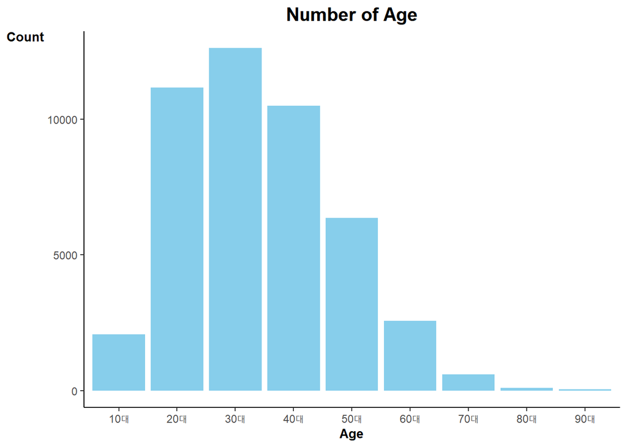

```r
data1 %>%
  ggplot2::ggplot(mapping = aes(x = age.group))+
  ggplot2::geom_bar(fill = "skyblue")+
  ggplot2::theme_classic()+
  ggplot2::labs(title = "Number of Age",
                x     = "Age",
                y     = "Count") +
  ggplot2::theme(plot.title = element_text(size  = 15,
                                           face  = "bold",
                                           hjust = 0.5),
                 axis.title.x = element_text(size = 10,
                                             face = "bold"),
                 axis.title.y = element_text(size  = 10,
                                             face  = "bold",
                                             angle = 0,
                                             vjust = 1.0))
```

#### education.group의 막대 그래프

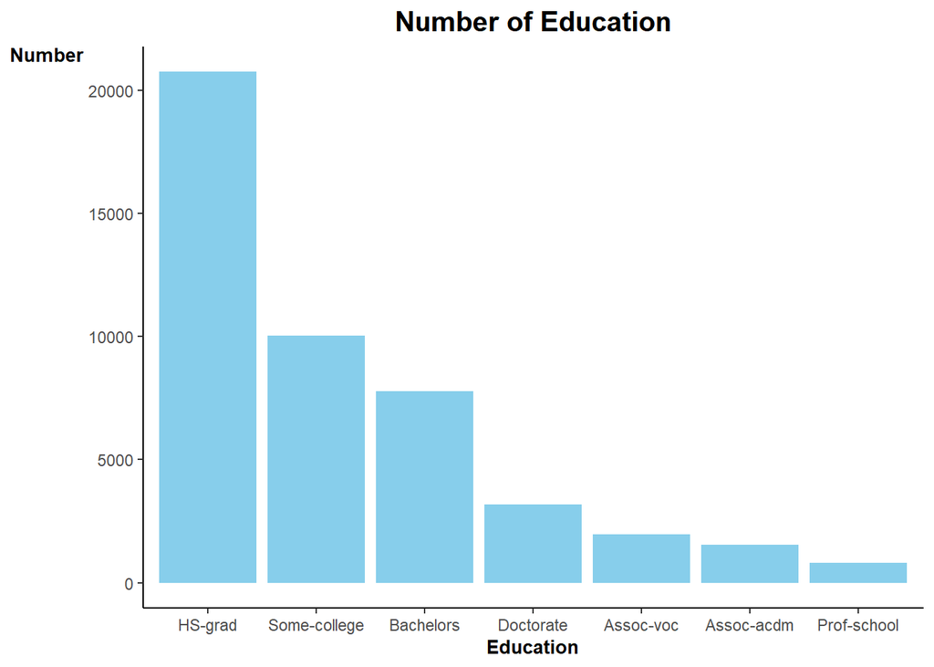

```r
data1 %>%
  dplyr::group_by(education.group) %>%
  dplyr::summarise(n = n()) %>%
  ggplot2::ggplot(mapping = aes(x = reorder(education.group, -n), y = n))+
  ggplot2::geom_bar(fill = "skyblue",stat = "identity") +
  ggplot2::theme_classic()+
  ggplot2::labs(title = "Number of Education",
                x     = "Education",
                y     = "Number") +
  ggplot2::theme(plot.title = element_text(size  = 15,
                                           face  = "bold",
                                           hjust = 0.5),
                 axis.title.x = element_text(size = 10,
                                             face = "bold"),
                 axis.title.y = element_text(size  = 10,
                                             face  = "bold",
                                             angle = 0,
                                             vjust = 1.0))
```

#### workclass의 막대 그래프

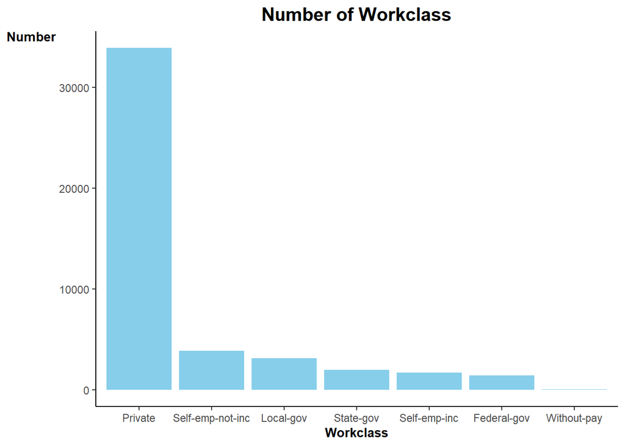

```r
data1 %>%
  dplyr::group_by(workclass) %>%
  dplyr::summarise(n = n()) %>%
  ggplot2::ggplot(mapping = aes(x = reorder(workclass, -n), y = n))+
  ggplot2::geom_bar(fill = "skyblue",stat = "identity") +
  ggplot2::theme_classic()+
  ggplot2::labs(title = "Number of Workclass",
                x     = "Workclass",
                y     = "Number")+
  ggplot2::theme(plot.title = element_text(size  = 15,
                                           face  = "bold",
                                           hjust = 0.5),
                 axis.title.x = element_text(size = 10,
                                             face = "bold"),
                 axis.title.y = element_text(size  = 10,
                                             face  = "bold",
                                             angle = 0,
                                             vjust = 1.0))
```

#### occupation 막대 그래프

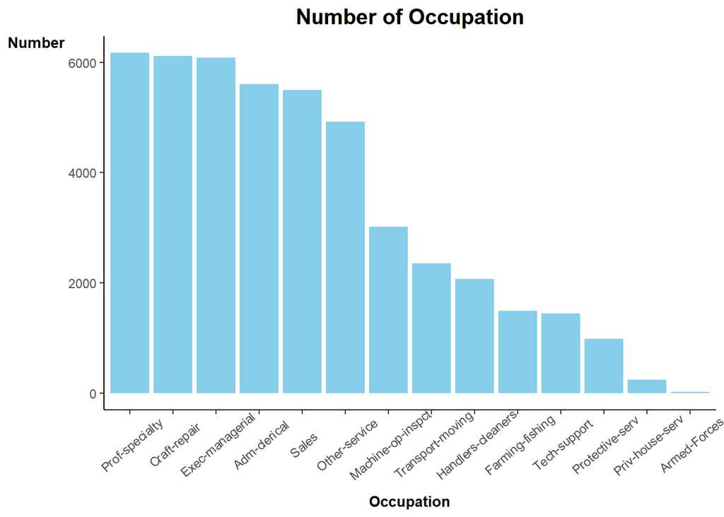

```r
data1 %>%
  dplyr::group_by(occupation) %>%
  dplyr::summarise(n = n()) %>%
  ggplot2::ggplot(mapping = aes(x = reorder(occupation, -n), y = n))+
  ggplot2::geom_bar(fill = "skyblue",stat = "identity") +
  ggplot2::theme_classic()+
  ggplot2::labs(title = "Number of Occupation",
                x     = "Occupation",
                y     = "Number")+
  ggplot2::theme(plot.title = element_text(size  = 15,
                                           face  = "bold",
                                           hjust = 0.5),
                 axis.title.x = element_text(size = 10,
                                             face = "bold"),
                 axis.title.y = element_text(size  = 10,
                                             face  = "bold",
                                             angle = 0,
                                             vjust = 1.0),
                 axis.text.x = element_text(angle = 40,
                                            vjust = 0.65))
```

#### hour.group 막대 그래프

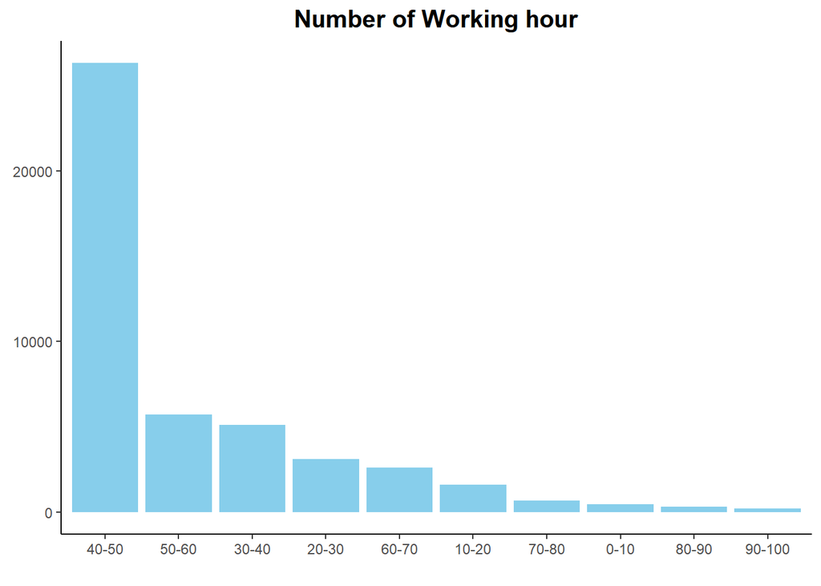

```r
data1 %>%
  dplyr::group_by(hour.group) %>%
  dplyr::summarise(n = n()) %>%
  ggplot2::ggplot(mapping = aes(x = reorder(hour.group,-n), y = n)) +
  ggplot2::geom_bar(stat = "Identity", fill = "skyblue") +
  ggplot2::theme_classic() +
  ggplot2::labs(title = "Number of Working hour",
                x     = "",
                y     = "")+
  ggplot2::theme(plot.title = element_text(size  = 15,
                                           face  = "bold",
                                           hjust = 0.5),
                 axis.title.x = element_text(size = 10,
                                             face = "bold"),
                 axis.title.y = element_text(size  = 10,
                                             face  = "bold",
                                             angle = 0,
                                             vjust = 1.0))
```

#### gender 막대 그래프 & 원 그래프

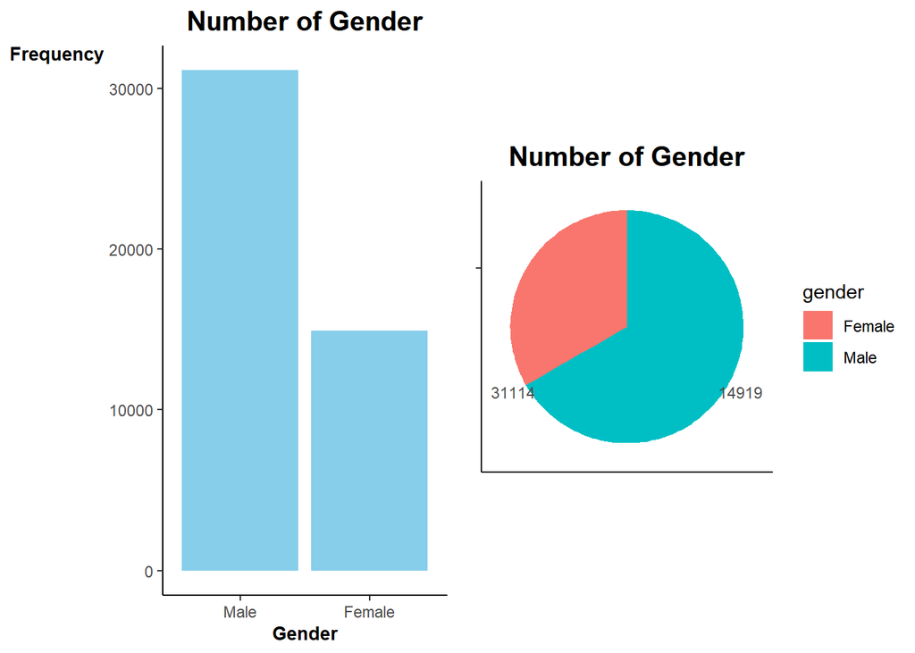

```r
gender.1 <- data1 %>%
  dplyr::group_by(gender) %>%
  dplyr::summarise(n = n()) %>%
  ggplot2::ggplot(mapping = aes(x = reorder(gender,-n), y = n)) +
  ggplot2::geom_bar(stat = "Identity", fill = "skyblue") +
  ggplot2::theme_classic() +
  ggplot2::labs(title    = "Number of Gender",
                x        = "Gender",
                y        = "Frequency") +
  ggplot2::theme(plot.title = element_text(size  = 15,
                                           face  = "bold",
                                           hjust = 0.5),
                 axis.title.x = element_text(size = 10,
                                             face = "bold"),
                 axis.title.y = element_text(size  = 10,
                                             face  = "bold",
                                             angle = 0,
                                             vjust = 1.0))

# gender pie
gender.2 <-  data1 %>%
  dplyr::group_by(gender) %>%
  dplyr::summarise(n = n()) %>%
  ggplot2::ggplot(mapping = aes(x = "", y = reorder(n,n), fill = gender)) +
  ggplot2::geom_bar(stat = "identity") +
  ggplot2::coord_polar(theta = "y", start = 0) +
  ggplot2::theme_classic() +
  ggplot2::labs(title = "Number of Gender",
                x     = "",
                y     = "") +
  ggplot2::theme(plot.title = element_text(size  = 15,
                                           face  = "bold",
                                           hjust = 0.5),
                 axis.title.x = element_text(size = 10,
                                             face = "bold"),
                 axis.title.y = element_text(size  = 10,
                                             face  = "bold",
                                             angle = 0,
                                             vjust = 1.0))

grid.arrange(gender.1, gender.2, nrow=1, ncol= 2)
```

```r
table(data1$gender)
```

```
##
## Female   Male
##  14919  31114
```

#### income 막대 그래프 & 원 그래프

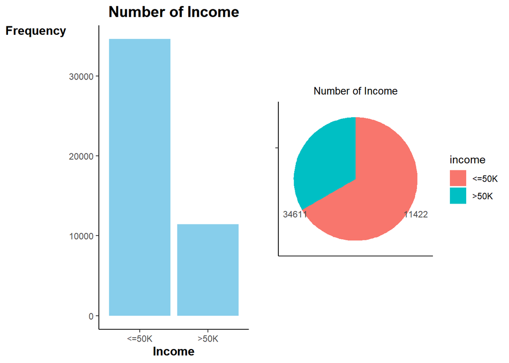

```r
income.1 <- data1 %>%
  dplyr::group_by(income) %>%
  dplyr::summarise(n = n()) %>%
  ggplot2::ggplot(mapping = aes(x = reorder(income,-n), y = n)) +
  ggplot2::geom_bar(stat = "Identity", fill = "skyblue") +
  ggplot2::theme_classic() +
  ggplot2::labs(title    = "Number of Income",
                x        = "Income",
                y        = "Frequency") +
  ggplot2::theme(plot.title = element_text(size  = 15,
                                           face  = "bold",
                                           hjust = 0.5),
                 axis.title.x = element_text(size = 12,
                                             face = "bold"),
                 axis.title.y = element_text(size  = 12,
                                             face  = "bold",
                                             angle = 0,
                                             vjust = 1))

# income pie
income.2 <- data1 %>%
  dplyr::group_by(income) %>%
  dplyr::summarise(n = n()) %>%
  ggplot2::ggplot(mapping = aes(x = "", y = reorder(n,n), fill = income)) +
  ggplot2::geom_bar(stat = "identity") +
  ggplot2::coord_polar(theta = "y", start = 0) +
  ggplot2::theme_classic() +
  ggplot2::labs(title = "Number of Income",
                x     = "",
                y     = "") +
  ggplot2::theme(plot.title = element_text(size = 10,
                                           hjust = .5))


grid.arrange(income.1, income.2, nrow=1, ncol= 2)
```

```r
table(data1$income)
```

```
##
## <=50K  >50K
## 34611 11422
```

#### race 막대 그래프

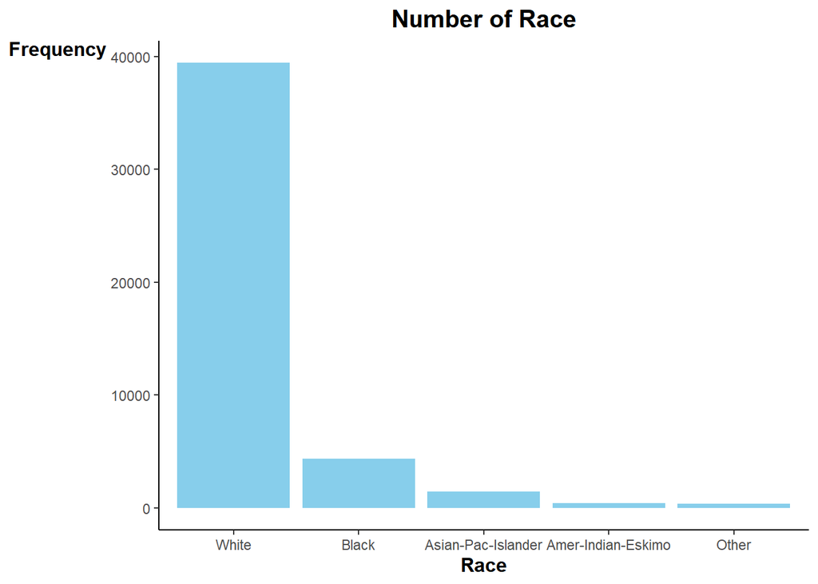

```r
data1 %>%
  dplyr::group_by(race) %>%
  dplyr::summarise(n = n()) %>%
  ggplot2::ggplot(mapping = aes(x = reorder(race,-n), y = n)) +
  ggplot2::geom_bar(stat = "Identity", fill = "skyblue") +
  ggplot2::theme_classic() +
  ggplot2::labs(title    = "Number of Race",
                x        = "Race",
                y        = "Frequency") +
  ggplot2::theme(plot.title = element_text(size  = 15,
                                           face  = "bold",
                                           hjust = 0.5),
                 axis.title.x = element_text(size = 12,
                                             face = "bold"),
                 axis.title.y = element_text(size  = 12,
                                             face  = "bold",
                                             angle = 0,
                                             vjust = 1))
```

### 이변량 질적자료 분석

## hour.group & income

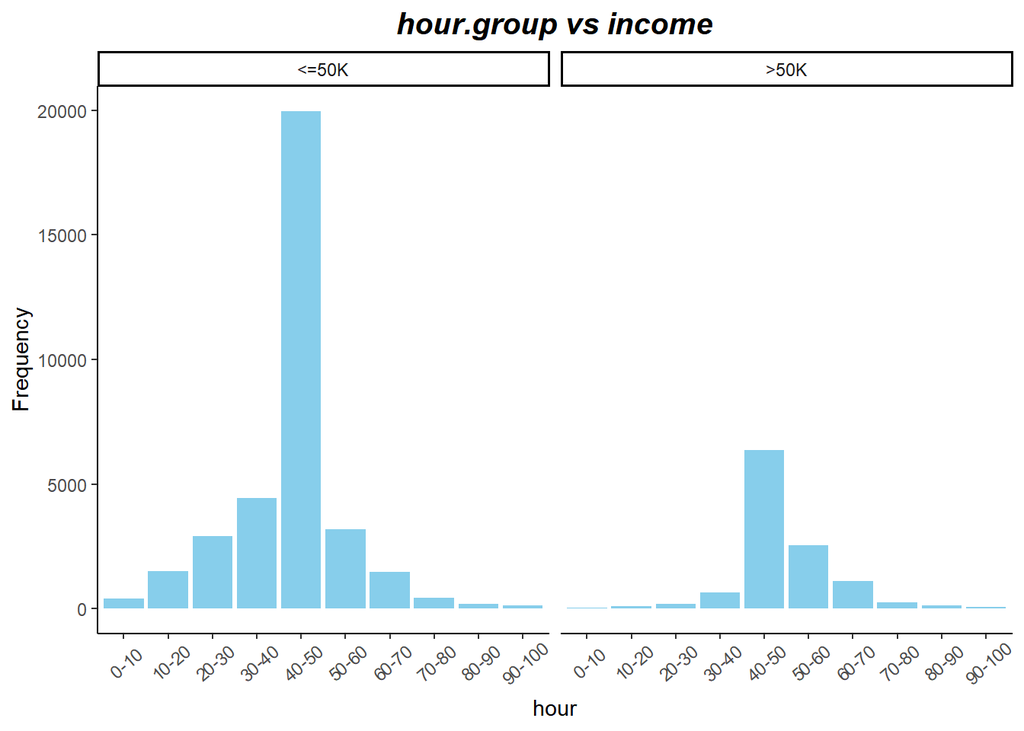

```r
label <-  c("<=50K",">50K")

data1 %>%
  ggplot2::ggplot(mapping = aes(x = hour.group)) +
  ggplot2::geom_bar(fill = "skyblue") +
  ggplot2::theme_classic() +
  ggplot2::labs(title = "hour.group vs income",
                x     = "hour",
                y     = "Frequency") +
  ggplot2::theme(plot.title = element_text(size = 15,
                                           color = "black",
                                           face = "bold.italic",
                                           hjust = 0.5),
                 axis.text.x = element_text(angle = 40,
                                            vjust = 0.65)) +
  ggplot2::facet_wrap(~income, nrow = 1, ncol = 2)
```

##### 최빈값은 40-50시간으로 동일하나 50K 이하인 그룹은 30-40시간이 두번째로 많은 반면,

##### 50K 초과인 그룹은 50-60 두번째로 많음

##### age.group & income

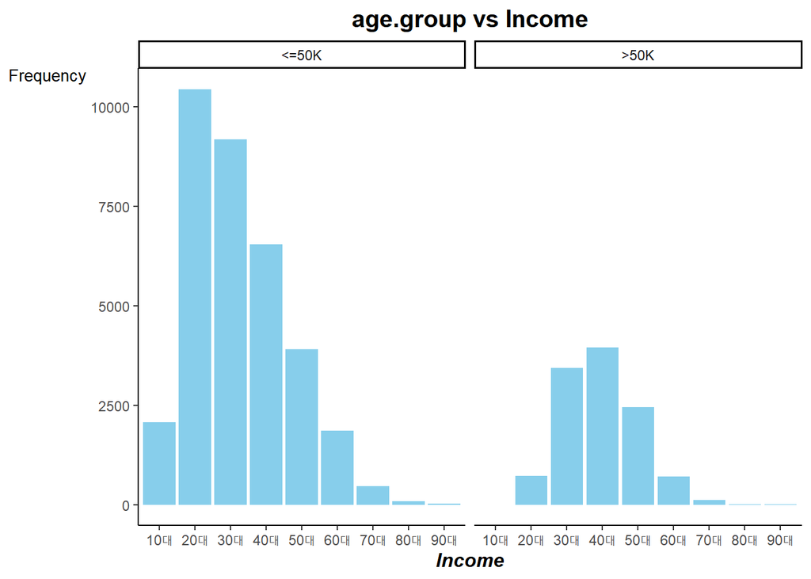

```r
data1 %>%
  ggplot2::ggplot(mapping = aes(x = age.group,)) +  # y 변수 설정
  ggplot2::geom_bar(position = "dodge", fill = "skyblue") +
  ggplot2::theme_classic() +
  ggplot2::labs(title = "age.group vs Income",
                x     = "Income",
                y     = "Frequency") +
  ggplot2::theme(plot.title = element_text(size = 15,
                                           color = "black",
                                           face = "bold",
                                           hjust = 0.5),
                 axis.title.x = element_text(size = 12,
                                             face = "bold.italic",
                                             color = "black"),
                 axis.title.y = element_text(size = 10,
                                             color = "black",
                                             angle = 0))+
  ggplot2::facet_wrap(~income, nrow = 1, ncol = 2)
```

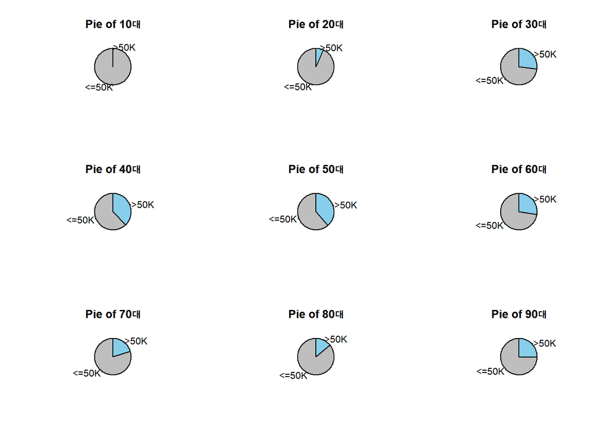

```r
par(mfrow = c(3,3))

for(i in 1:9){
  pie(c(table(data1$age.group, data1$income)[i,1] / (table(data1$age.group, data1$income)[i,1] + table(data1$age.group, data1$income)[i,2]), table(data1$age.group, data1$income)[i,2] / (table(data1$age.group, data1$income)[i,1] + table(data1$age.group, data1$income)[i,2])),
      radius    = 1,
      clockwise = FALSE,
      init.angle = 90,
      col = c("gray","skyblue"),
      main = paste("Pie of" , rownames(table(data1$age.group, data1$income))[i]),
      labels = label)
}
```

```r
par(mfrow = c(1,1))
```

##### 막대 그래프는 income별 age.group을 나타내며

##### 50K 이하인 그룹은 20대가 많은 반면, 50K 초과인 그룹은 40대가 가장 많고

##### 원 그래프는 age.group별 income을 나타내며

##### 각 연령대 별 income의 비율을 확인할 수 있었다

##### workclass vs income

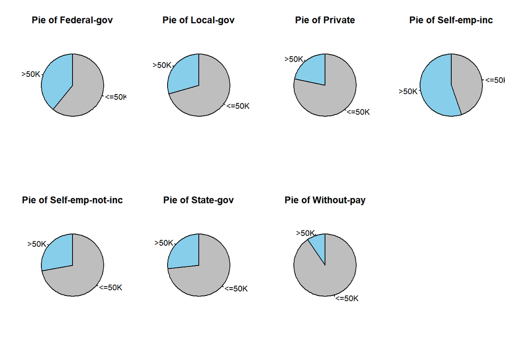

```r
par(mfrow = c(2,4))

for(i in 1:7){
  pie(c(table(data1$workclass, data1$income)[i,1] / (table(data1$workclass, data1$income)[i,1] + table(data1$workclass, data1$income)[i,2]), table(data1$workclass, data1$income)[i,2] / (table(data1$workclass, data1$income)[i,1] + table(data1$workclass, data1$income)[i,2])),
      radius    = 1,
      clockwise = TRUE,
      init.angle = 90,
      col = c("gray","skyblue"),
      main = paste("Pie of" , rownames(table(data1$workclass, data1$income))[i]),
      labels = label)
}
par(mfrow = c(1,1))
```

##### Self-emp-inc그룹에서만 수입이 50K를 초과하는 인원이 50%를 넘음

##### education.group & income

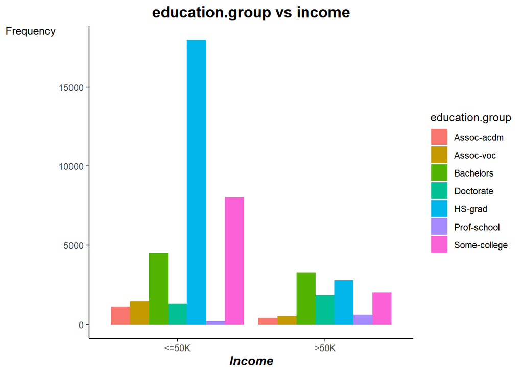

```r
label <-  c("<=50K",">50K")

data1 %>%
  ggplot2::ggplot(mapping = aes(x    = income,
                                fill = education.group)) +  # y 변수 설정
  ggplot2::geom_bar(position = "dodge") +
  ggplot2::theme_classic() +
  ggplot2::labs(title = "education.group vs income",
                x     = "Income",
                y     = "Frequency") +
  ggplot2::theme(plot.title = element_text(size = 15,
                                           color = "black",
                                           face = "bold",
                                           hjust = 0.5),
                 axis.title.x = element_text(size = 12,
                                             face = "bold.italic",
                                             color = "black"),
                 axis.title.y = element_text(size = 10,
                                             color = "black",
                                             angle = 0))
```

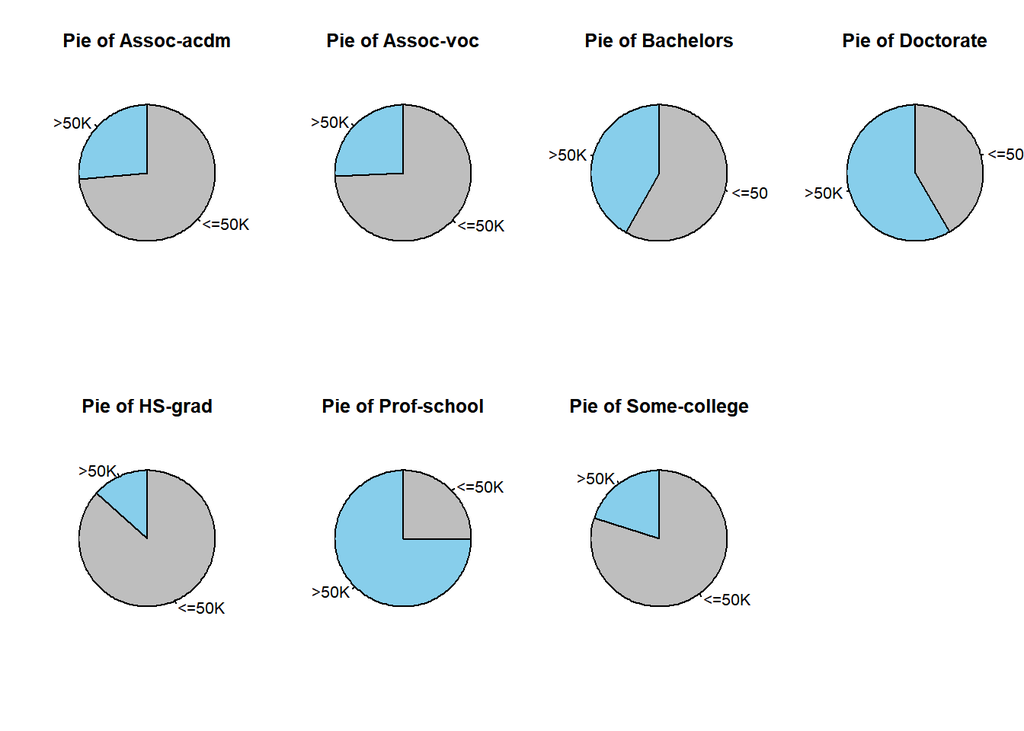

```r
par(mfrow = c(2,4))

for(i in 1:7){
  pie(c(table(data1$education.group, data$income)[i,1] / (table(data1$education.group, data$income)[i,1] + table(data1$education.group, data$income)[i,2]), table(data1$education.group, data$income)[i,2] / (table(data1$education.group, data$income)[i,1] + table(data1$education.group, data$income)[i,2])),
      radius    = 1.08,
      clockwise = TRUE,
      init.angle = 90,
      col = c("gray","skyblue"),
      main = paste("Pie of" , rownames(table(data1$education.group, data$income))[i]),
      labels = label)
}

par(mfrow = c(1,1))
```

##### 50K이하인 그룹은 Hs-grad가 가장 많은 반면,

##### 50K초과인 그룹은 Bachelors가 가장 많음

##### Doctorate그룹과 Prof-School그룹은 >50K가 절반이상의 비율을 보였음

##### occupation & gender

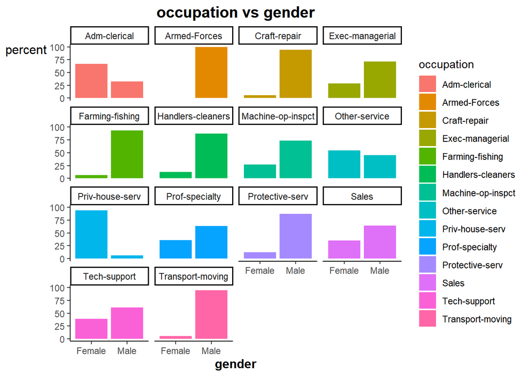

```r
data1 %>%
  dplyr::group_by(occupation, gender) %>%
  dplyr::summarise(n = n()) %>%
  dplyr::mutate(percent = round((n/sum(n))*100 , digits = 1)) %>%
  dplyr::arrange(desc(percent)) %>%
  ggplot2::ggplot(mapping = aes(x = gender, y = percent, fill = occupation)) +
  ggplot2::geom_bar(position = "dodge", stat="identity") +
  ggplot2::theme_classic() +
  ggplot2::labs(title = "occupation vs gender",
                x     = "gender",
                y     = "percent") +
  ggplot2::theme(plot.title = element_text(size = 15,
                                           color = "black",
                                           face = "bold",
                                           hjust = 0.5),
                 axis.title.x = element_text(size = 12,
                                             color = "black",
                                             face = "bold"),
                 axis.title.y = element_text(size = 12,
                                             color = "black",
                                             angle = 0)) +
  ggplot2::facet_wrap(~occupation)
```

##### education.group vs race

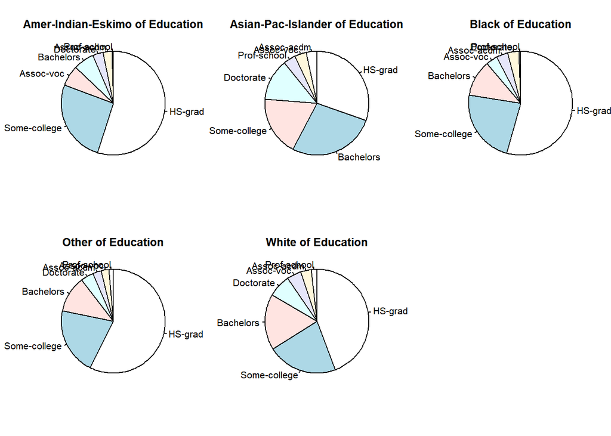

```r
par(mfrow = c(2,3))
for(i in 1:5){
  pie(sort(c((table(data1$education.group,data1$race)[ ,i][1]) / (sum(table(data1$education.group,data1$race)[ ,i]))*100,
             (table(data1$education.group,data1$race)[ ,i][2]) / (sum(table(data1$education.group,data1$race)[ ,i]))*100,
             (table(data1$education.group,data1$race)[ ,i][3]) / (sum(table(data1$education.group,data1$race)[ ,i]))*100,
             (table(data1$education.group,data1$race)[ ,i][4]) / (sum(table(data1$education.group,data1$race)[ ,i]))*100,
             (table(data1$education.group,data1$race)[ ,i][5]) / (sum(table(data1$education.group,data1$race)[ ,i]))*100,
             (table(data1$education.group,data1$race)[ ,i][6]) / (sum(table(data1$education.group,data1$race)[ ,i]))*100,
             (table(data1$education.group,data1$race)[ ,i][7]) / (sum(table(data1$education.group,data1$race)[ ,i]))*100),decreasing = TRUE),
      radius     = 1,
      clockwise  = TRUE,
      init.angle = 90,
      main       = paste(colnames(table(data1$education.group,data1$race))[i], "of Education"))
}
par(mfrow = c(1,1))
```